# MAF Visualization of somatic mutations in cell lines

Florencia Zuniga

7/17/2019

THIS IS AN UNREFINED DATA JUST TO SHOW THE GENERAL IDEA OF WHAT THESE RESULTS WILL LOOK LIKE IN A COUPLE DAYS

## 1. LOADING DATA (#anchor1)

Needed libraries:

```r
library(readr)
library(rstudioapi)
library(maftools)
```

Reading the data

```r
Untreated <- readRDS(paste0(wd,"/data/NCI_TPW_gep_untreated.rds"))
Treated <- readRDS(paste0(wd,"/data/NCI_TPW_gep_treated.rds"))

Metadata = read.table(paste0(wd,"/data/NCI_TPW_metadata.tsv"),
                      header = TRUE, sep ="\t", stringsAsFactors = TRUE)

Sensitivity <- readRDS(paste0(wd,"/data/NegLogGI50.rds"))


Basal <- readRDS(paste0(wd,"/data/CCLE_basalexpression.rds"))
Copynumber <- readRDS(paste0(wd,"/data/CCLE_copynumber.rds"))
Mutations <- readRDS(paste0(wd,"/data/CCLE_mutations.rds"))

Cellline_annotation = read.table(paste0(wd,"/data/cellline_annotation.tsv"),
                                 header = TRUE, sep ="\t", stringsAsFactors = TRUE)
Drug_annotation = read.table(paste0(wd,"/data/drug_annotation.tsv"),
                             header = TRUE, sep ="\t", stringsAsFactors = TRUE)
```

Transforming the data

```r
Treated <- as.data.frame(Treated)
Untreated <- as.data.frame(Untreated)
Sensitivity<- as.data.frame(Sensitivity)
```

Data normalization

```r
Untreated_norm <- apply(Untreated, 2, function(x){
  (x - mean(x)) / sd(x)
 })
```

```r
Treated_norm <- apply(Treated, 2, function(x){
  (x - mean(x)) / sd(x)
 })


FC <- Treated - Untreated
FC_norm <- apply(FC, 2, function(x){
  (x - mean(x)) / sd(x)
 })
```

## 1.1 Biomarkers (#anchor2)

### (1) Creating Vorinostat

```r
#Untreated matrix
UntreatedVorinostatcolumns <- grep(pattern = "vorinostat",colnames(Untreated))

#Same with treated matrix
TreatedVorinostatcolumns <- grep(pattern = "vorinostat",colnames(Treated))

#Define Vorinostat-data:
UntreatedVorinostat <- Untreated[,UntreatedVorinostatcolumns]
TreatedVorinostat <- Treated[,TreatedVorinostatcolumns]

#fold change matrix
FC <- TreatedVorinostat - UntreatedVorinostat

#Sensitivity
vorinostat_Sensitivity_alleZeilen= grep ('vorinostat', rownames(Sensitivity))
vorinostat_Sensitivity_data= Sensitivity[vorinostat_Sensitivity_alleZeilen,]
```

### (2) Creating FC Data - Finding the Biomarkers

```r
FC <- TreatedVorinostat - UntreatedVorinostat

#We work with mean of the rows because we only want to compare the genes
FC_meanrow= rowMeans(FC)

## Sorting the data
#We work with absolute value to find the highest values,
#because we want to have the most up and down regulated genes.
FC_abs= abs(FC_meanrow)

#We sort the values to get the 100 largest values
sortedFC_abs <- sort(FC_abs, decreasing = TRUE)
sortedFC_abs <- as.matrix(sortedFC_abs)

#We select the first n for biomarkers
biomarkers_FC30 = sortedFC_abs[1:30,]
biomarkers_FC30 <- as.matrix(biomarkers_FC30)

biomarkers_FC100 = sortedFC_abs[1:100,]
biomarkers_FC100 <- as.matrix(biomarkers_FC100)

## Creating a matrix with FC values, that are both positive and negative
FC_both= cbind(FC_meanrow,FC_abs)
FC_both=as.data.frame(FC_both)

#Ordering this matrix
FC_both_sorted <- FC_both[order(FC_both$FC_abs, decreasing = TRUE),]

#FC values of biomarkers: We select the first 100 of the sorted matrix.
biomarkers_FC_values30 = FC_both_sorted[1:30,]

biomarkers_FC_values100 = FC_both_sorted[1:100,]

#Removing the absolute values
biomarkers_FC_values30 <- subset( biomarkers_FC_values30, select = -FC_abs)
biomarkers_FC_values30 = as.matrix(biomarkers_FC_values30)

biomarkers_FC_values100 <- subset( biomarkers_FC_values100, select = -FC_abs)
biomarkers_FC_values100 = as.matrix(biomarkers_FC_values100)
```

## Creating a polished MAF file

### Editing the original mutation file, so that the table has all the columns that are needed so that it can be read with the package

```r
Mutations <- readRDS(paste0(wd,"/data/CCLE_mutations.rds"))

names(Mutations)[names(Mutations) == "Tumor_Seq_Allele1"] <- "Tumor_Seq_Allele2"
names(Mutations)[names(Mutations) == "Start_position"] <- "Start_Position"
names(Mutations)[names(Mutations) == "End_position"] <- "End_Position"
names(Mutations)[names(Mutations) == "Hugo_Symbol"] <- "Hugo_Symbol"
rownames(Mutations) <- c()
MutationsT <- Mutations[,c(1,4,5,6,10,11,8,9,16,2,3,7,12,13,14,15,17,18)]
```

### Create a file with all genes

```r
write.table(MutationsT, file = "MutationsT.csv", row.names = F, sep = "\t")
```

### Creating a MAF file

```r
laml <- read.maf(maf ="C:/GitHub/project-02-group-05/MutationsT.csv", useAll = T, verbose = T)
```

```
## -Reading
## -Validating
## --Removed 12 duplicated variants
## --Non MAF specific values in Variant_Classification column:
##   Stop_Codon_Ins
##   Start_Codon_Del
## -Silent variants: 18801
## -Summarizing
## --Possible FLAGS among top ten genes:
##   TTN
##   MUC16
##   NEB
##   OBSCN
## -Processing clinical data
## --Missing clinical data
## -Finished in 8.090s elapsed (6.110s cpu)
```

```r
laml
```

```
## An object of class  MAF
##                    ID summary    Mean Median
##  1:        NCBI_Build      37      NA     NA
##  2:            Center      NA      NA     NA
##  3:           Samples      58      NA     NA
##  4:            nGenes   15286      NA     NA
##  5:   Frame_Shift_Del    2936  50.621   10.0
##  6:   Frame_Shift_Ins    1376  23.724   14.0
##  7:      In_Frame_Del     335   5.776    4.0
##  8:      In_Frame_Ins     158   2.724    2.0
##  9: Missense_Mutation   43449 749.121  325.5
## 10: Nonsense_Mutation    2934  50.586   19.0
## 11:  Nonstop_Mutation      67   1.155    0.5
## 12:       Splice_Site    2704  46.621   19.5
## 13:             total   53959 930.328  387.0
```

## Create a File with 100 Biomarkers

```r
BM_mut = MutationsT[ which((MutationsT$Hugo_Symbol)
                                  %in% rownames(biomarkers_FC_values100)), ]

write.table(BM_mut, file = "BM_mut.csv", row.names = F, sep = "\t")

BM_laml <- read.maf(maf ="C:/GitHub/project-02-group-05/BM_mut.csv", useAll = T, verbose = T)
```

```
## -Reading
## -Validating
## -Silent variants: 78
## -Summarizing
## -Processing clinical data
## --Missing clinical data
## -Finished in 0.250s elapsed (0.190s cpu)
```

## Mutations in all genes

### Generating summaries

```r
write.mafSummary(maf = laml, basename = 'laml')
```

### Visualizations

#### Ploting MAF summary

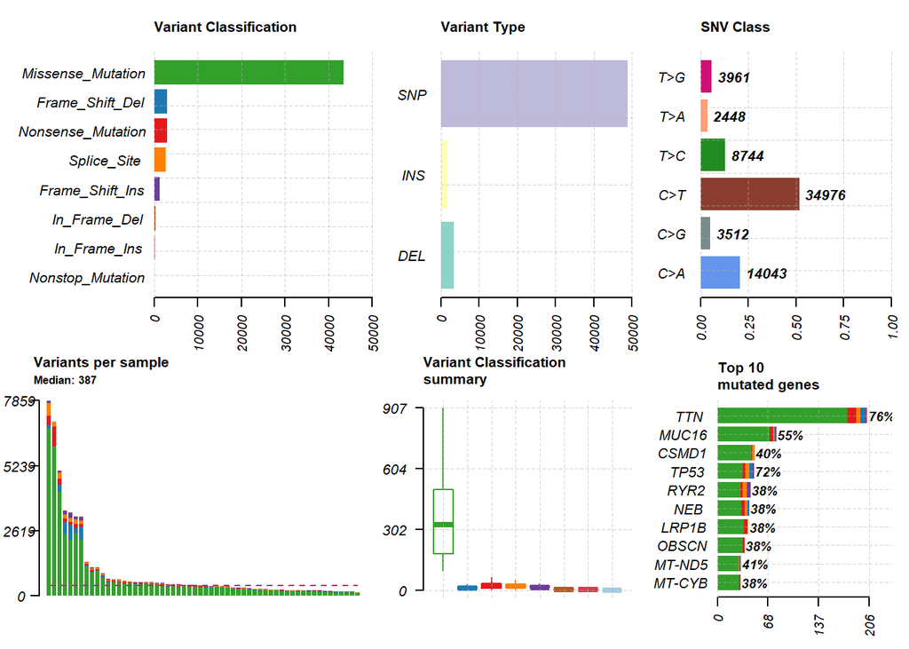

```r
plotmafSummary(maf = laml, rmOutlier = TRUE, addStat = 'median', dashboard = TRUE, titvRaw = FALSE)
```

#### Ploting oncoplot with Transversions/Transitions

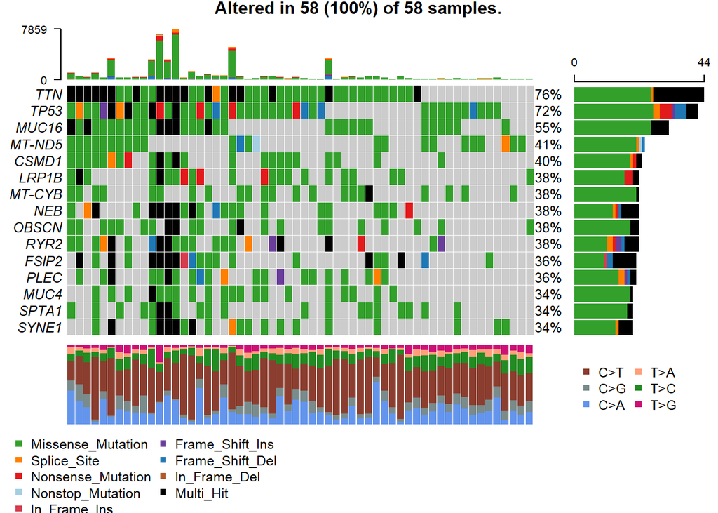

```r
oncoplot(maf = laml, top = 15, draw_titv = TRUE)
```

##### oncoplot(maf = laml, top = 15, draw_titv = TRUE, additionalFeature = c(“Tumor_Sample_Barcode”, “MALME-3M”))

#Altered in all samples as this are all cancer cell lines

#### Oncoplot expression values

```r
set.seed(seed = 1024)
exprs_tbl = data.frame(genes = getGeneSummary(x = laml)[1:20, Hugo_Symbol],
                       exprn = rnorm(n = 10, mean = 12, sd = 5))
head(exprs_tbl)
```

[output not shown]

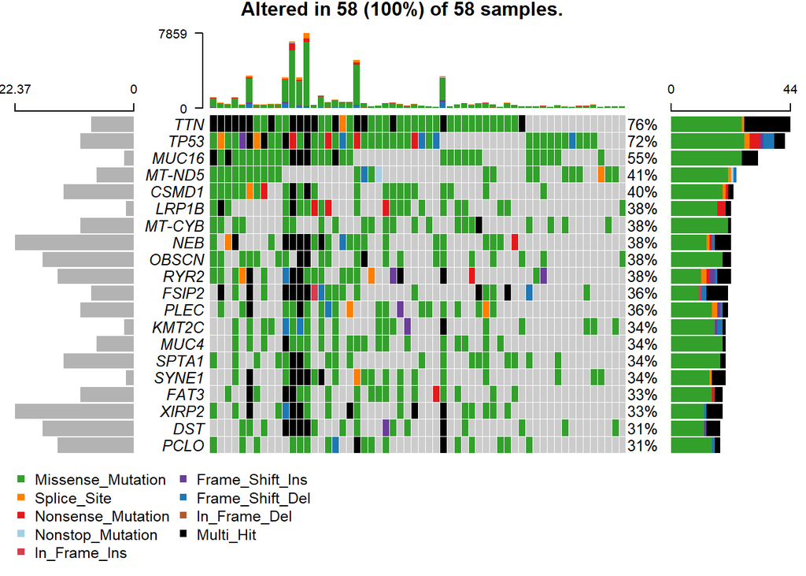

```r
oncoplot(maf = laml, exprsTbl = exprs_tbl)
```

#### Oncostrips for the top10 biomarkers

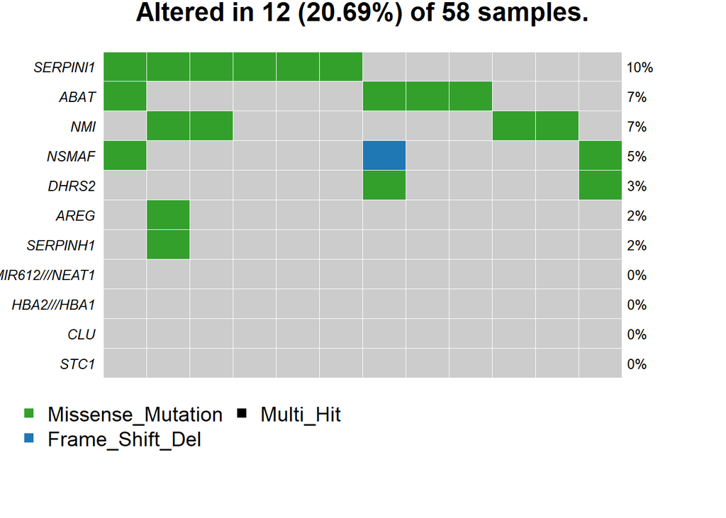

```r
oncostrip(maf = laml, genes = c('DHRS2',
                                'ABAT',
                                'SERPINI1',
                                'MIR612///NEAT1 ',
                                'HBA2///HBA1    ',
                                'CLU',
                                'NMI',
                                'STC1',
                                'AREG',
                                'NSMAF',
                                'SERPINH1')
          )
```

#### Oncostrips for the 10 genes with the least change in expression

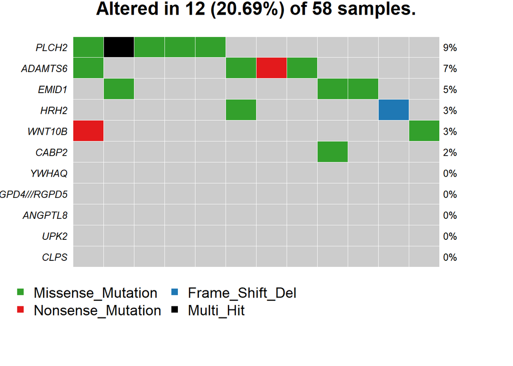

```r
oncostrip(maf = laml, genes = c('ADAMTS6',
                                'YWHAQ',
                                'EMID1',
                                'PLCH2',
                                'HRH2',
                                'WNT10B',
                                'RGPD6///RGPD8///RGPD3///RGPD4///RGPD5',
                                'ANGPTL8',
                                'CABP2',
                                'UPK2',
                                'CLPS')
        )
```

#### Transitions and Transversion

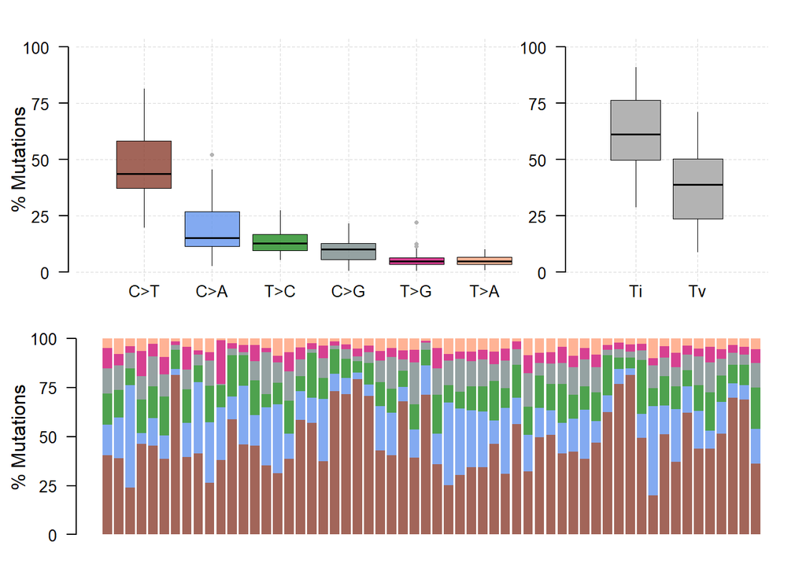

```r
laml.titv = titv(maf = laml, plot = FALSE, useSyn = TRUE)

#plot titv summary
plotTiTv(res = laml.titv)
```

#### Mutation load vs TCGA cohorts

```r
laml.mutload = tcgaCompare(maf = laml, cohortName = 'Example-LAML')
```

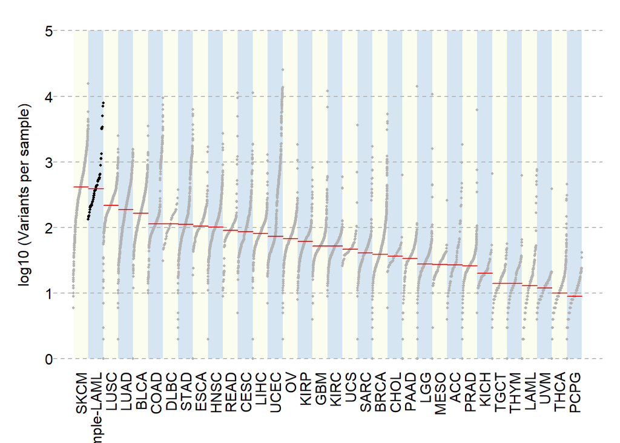

#### Somatic interactions

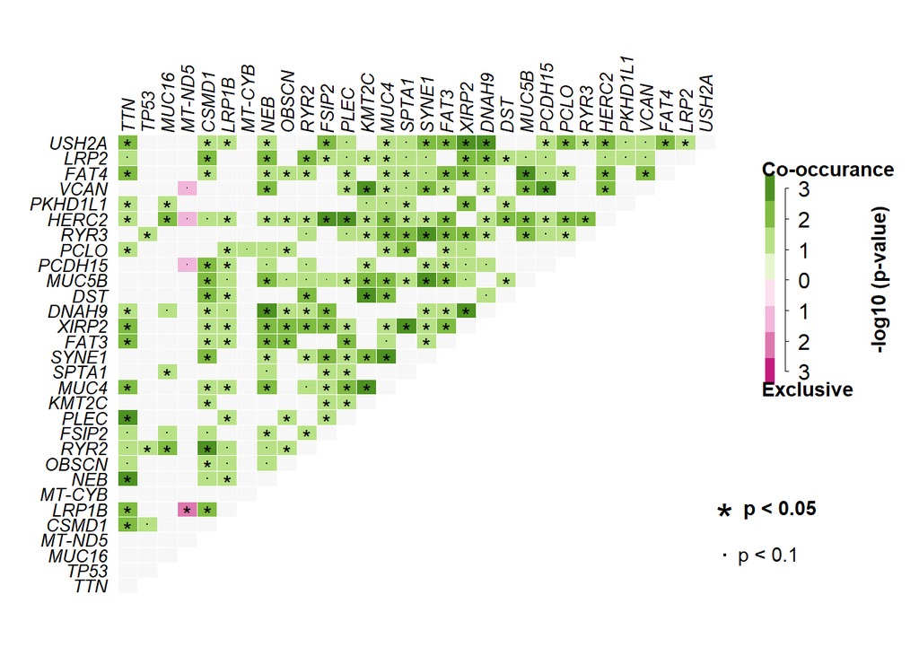

```
## Checking for Gene sets
## ------------------
## genes: 5
## geneset size: 3
## 10 combinations
## Signifcantly altered gene-sets: 1
## ------------------
```

```
## [[1]]
## [[1]]$pairs
##       gene1  gene2       pValue  oddsRatio 00 11 01 10              Event
##   1:  USH2A  XIRP2 5.504229e-05 14.0423124 35 12  7  4       Co_Occurance
##   2:   VCAN PCDH15 6.595420e-05 13.1259785 35 12  6  5       Co_Occurance
##   3:   MUC4  KMT2C 8.051493e-05 11.7362366 32 14  6  6       Co_Occurance
##   4:   RYR2  CSMD1 8.669148e-05 10.4728993 29 16  7  6       Co_Occurance
##   5:   RYR3  SYNE1 1.677523e-04 11.5616537 33 13  7  5       Co_Occurance
##  ---
## 224: MT-ND5  HERC2 8.850156e-02  0.3292542 21  4 13 20 Mutually_Exclusive
## 225: MT-ND5   VCAN 8.850156e-02  0.3292542 21  4 13 20 Mutually_Exclusive
## 226:  DNAH9  MUC16 9.514840e-02  2.8219382 21 13 19  5       Co_Occurance
## 227:    NEB  CSMD1 9.834834e-02  2.6777301 25 12 11 10       Co_Occurance
## 228:  MUC16  FSIP2 9.862900e-02  2.8861297 20 15  6 17       Co_Occurance
##
## [[1]]$gene_sets
##                 gene_set     pvalue
## 1: LRP1B, PCDH15, MT-ND5 0.04964611
```

```r
pairlist(somaticInteractions(maf = laml, top = 30, pvalue = c(0.05, 0.1)))
```

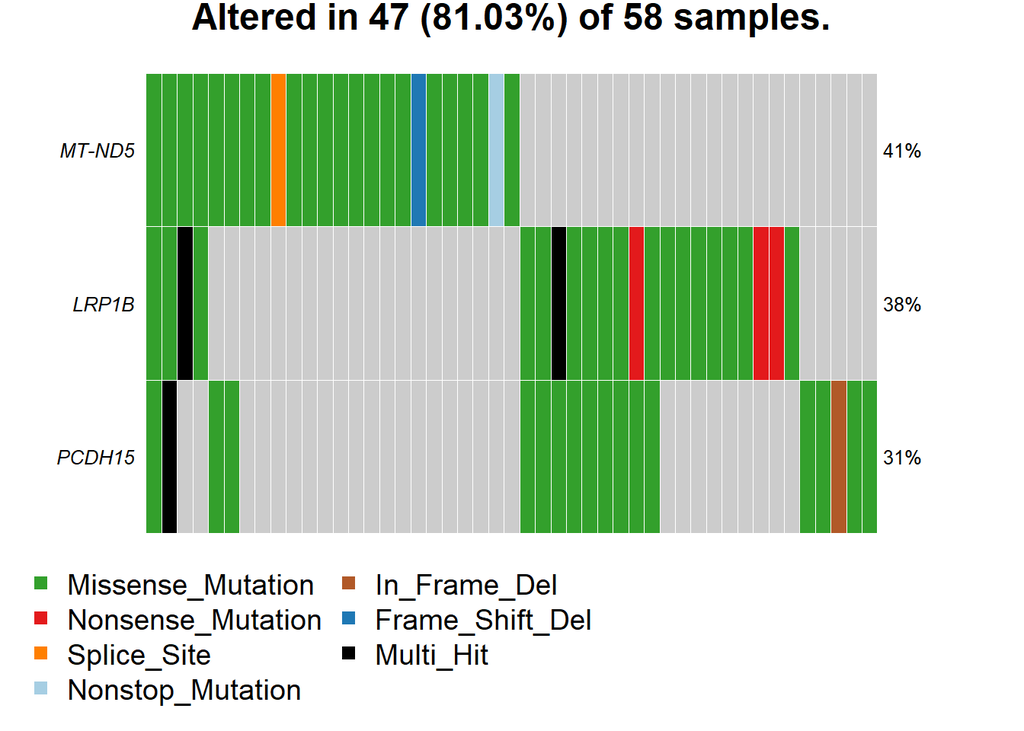

```r
oncostrip(maf = laml, genes = c('LRP1B', 'PCDH15', 'MT-ND5'))
```

# Drug Gene interactions

```r
dgi = drugInteractions(maf = laml, fontSize = 0.75)
```

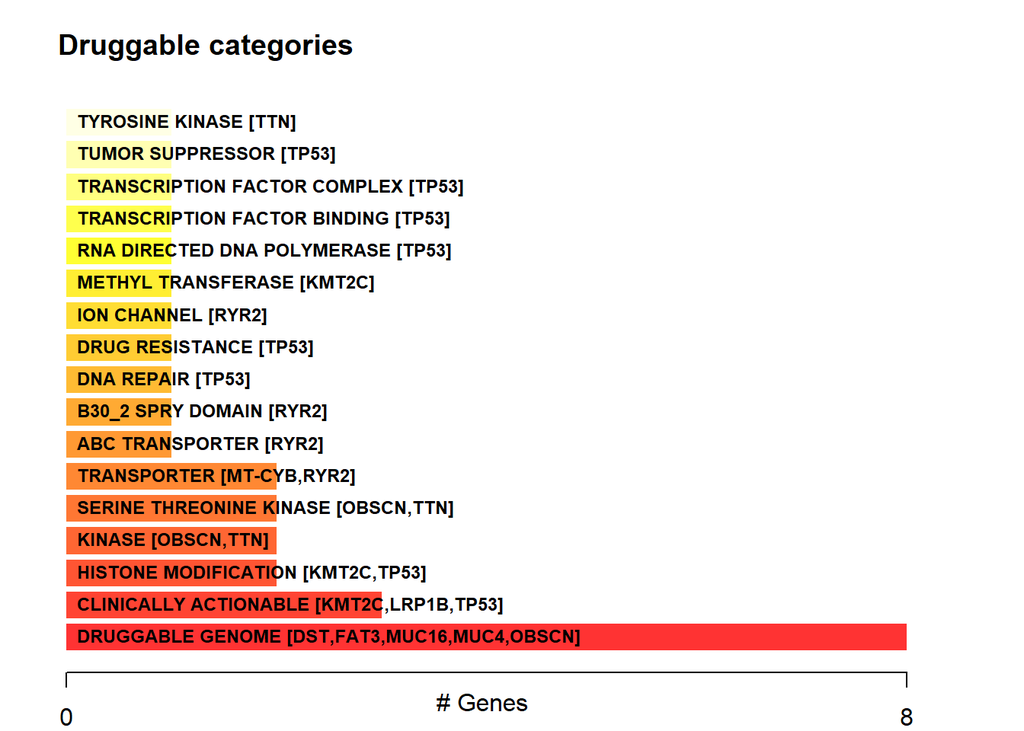

```r
dnmt3a.dgi = drugInteractions(genes = "MUC16", drugs = TRUE)
```

```
## Number of claimed drugs for given genes:
##     Gene  N
## 1: MUC16 15
```

```r
dnmt3a.dgi[,.(Gene, interaction_types, drug_name, drug_claim_name)]
```

```
##      Gene interaction_types         drug_name        drug_claim_name
##  1: MUC16                          ABAGOVOMAB          CHEMBL1742981
##  2: MUC16                                     DIFFERENTIATING AGENTS
##  3: MUC16                           DOCETAXEL              DOCETAXEL
##  4: MUC16                        CYCLOSPORINE           CYCLOSPORINE
##  5: MUC16                                                        N/A
##  6: MUC16                           TOPOTECAN              TOPOTECAN
##  7: MUC16                          OREGOVOMAB                 B43.13
##  8: MUC16                          ABAGOVOMAB             ABAGOVOMAB
##  9: MUC16                          OREGOVOMAB          CHEMBL2107917
## 10: MUC16                          OREGOVOMAB             OREGOVAMAB
## 11: MUC16                     SODIUM BUTYRATE        SODIUM BUTYRATE
## 12: MUC16                           TAMOXIFEN              TAMOXIFEN
## 13: MUC16                   BUSERELIN ACETATE      BUSERELIN ACETATE
## 14: MUC16                           ETOPOSIDE              ETOPOSIDE
## 15: MUC16                                                        IFN
```

```r
OncogenicPathways(maf = laml)
```

```
## Pathway alteration fractions
```

```
##        Pathway  N n_affected_genes fraction_affected
##  1:    RTK-RAS 85               78         0.9176471
##  2:        WNT 68               60         0.8823529
##  3:      NOTCH 71               60         0.8450704
##  4:      Hippo 38               35         0.9210526
##  5:       PI3K 29               25         0.8620690
##  6: Cell_Cycle 15               14         0.9333333
##  7:        MYC 13               11         0.8461538
##  8:   TGF-Beta  7                7         1.0000000
##  9:       TP53  6                6         1.0000000
## 10:       NRF2  3                3         1.0000000
```

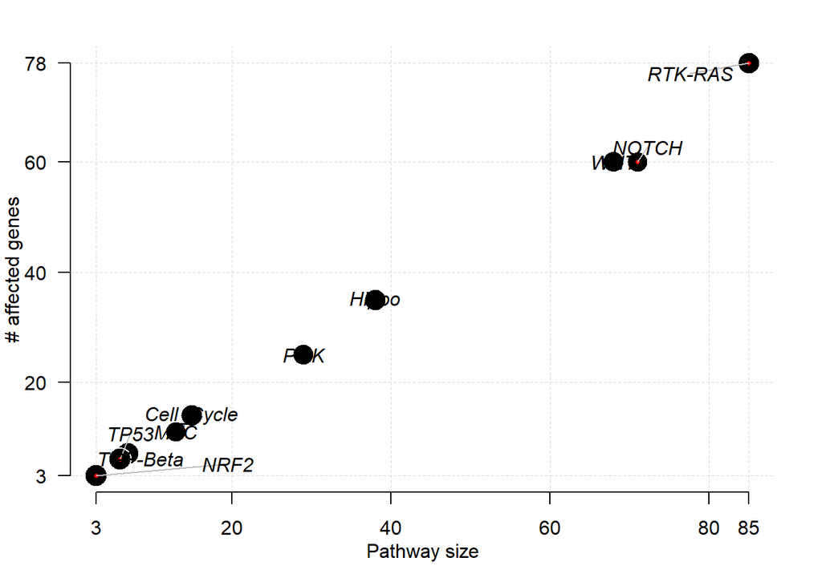

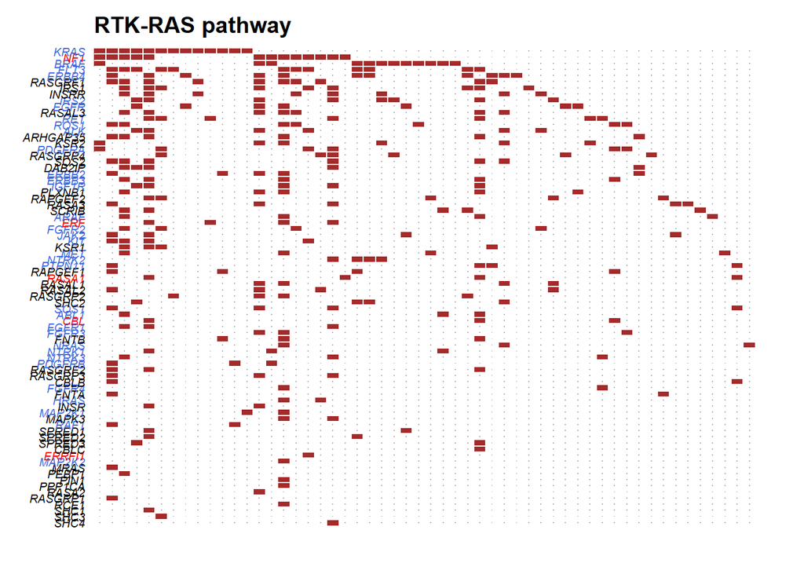

```r
PlotOncogenicPathways(maf = laml, pathways = "RTK-RAS")
```

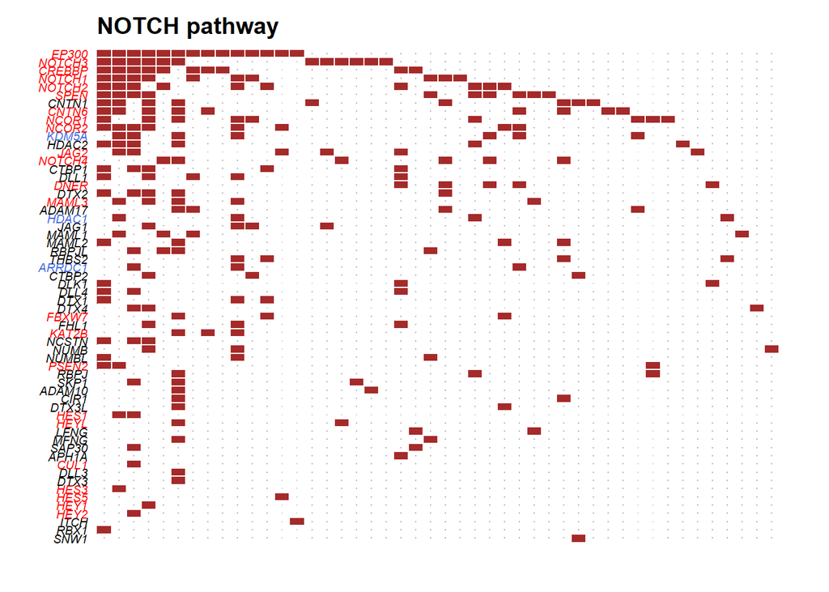

```r
PlotOncogenicPathways(maf = laml, pathways = "NOTCH")
```

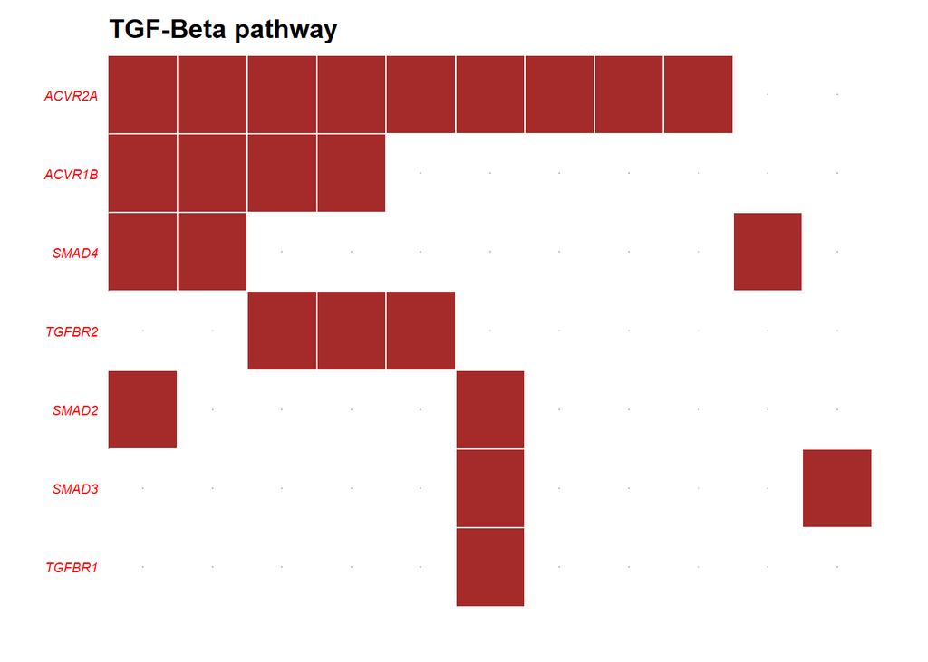

```r
PlotOncogenicPathways(maf = laml, pathways = "TGF-Beta")
```

if (!requireNamespace(“BiocManager”, quietly = TRUE)) install.packages(“BiocManager”)

BiocManager::install(“BSgenome.Hsapiens.UCSC.hg19”)

library(BSgenome.Hsapiens.UCSC.hg19, quietly = TRUE)

if (!requireNamespace(“BiocManager”, quietly = TRUE)) install.packages(“BiocManager”) BiocManager::install()

BiocInstaller::biocValid()

biocLite(“stringi”) biocLite(“TxDb.Hsapiens.UCSC.hg19.knownGene”)

library(BiocManager)

library(BSgenome.Hsapiens.UCSC.hg19)

laml.tnm = trinucleotideMatrix(maf = laml, prefix = ‘chr’, add = TRUE, ref_genome = “BSgenome.Hsapiens.UCSC.hg19”) plotApobecDiff(tnm = laml.tnm, maf = laml, pVal = 0.2)

## Mutations in the biomarkers

```r
BM_laml
```

```
## An object of class  MAF
##                    ID summary  Mean Median
##  1:        NCBI_Build      37    NA     NA
##  2:            Center      NA    NA     NA
##  3:           Samples      50    NA     NA
##  4:            nGenes      67    NA     NA
##  5:   Frame_Shift_Del      21 0.477    0.0
##  6:   Frame_Shift_Ins       6 0.136    0.0
##  7: Missense_Mutation     151 3.432    1.5
##  8: Nonsense_Mutation       5 0.114    0.0
##  9:  Nonstop_Mutation       1 0.023    0.0
## 10:       Splice_Site       8 0.182    0.0
## 11:             total     192 4.364    2.0
```

##### Summaries

```r
write.mafSummary(maf = BM_laml, basename = 'laml')
```

### Visualization

##### Ploting MAF summary

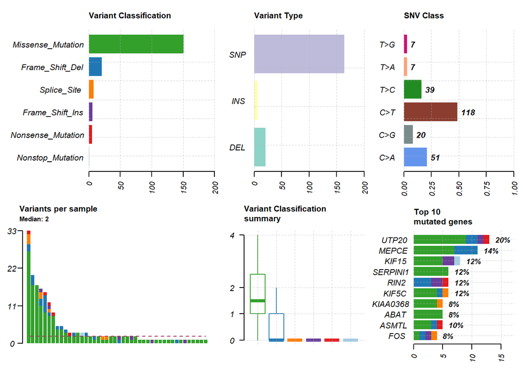

```r
plotmafSummary(maf = BM_laml, rmOutlier = TRUE, addStat = 'median', dashboard = TRUE, titvRaw = FALSE)
```

#### Ploting oncoplot

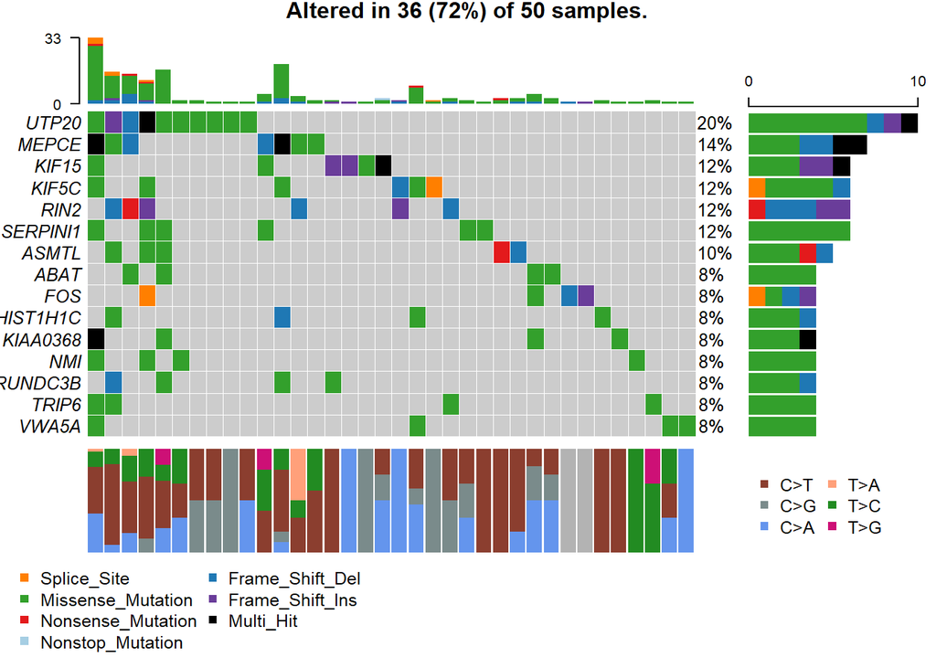

```r
oncoplot(maf = BM_laml, top = 15, draw_titv = TRUE)
```

#### Oncostrips for the top10 biomarkers

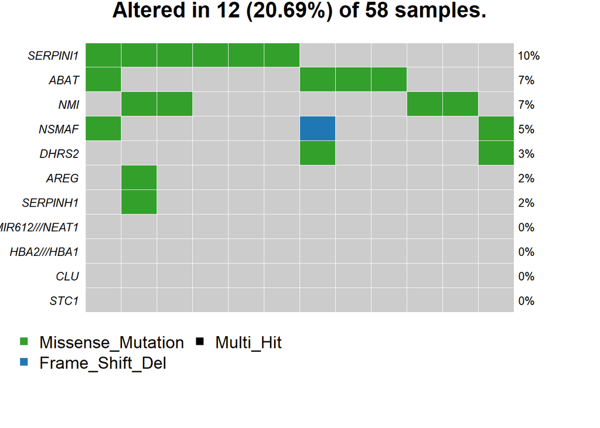

```r
oncostrip(maf = laml, genes = c('DHRS2',
                                'ABAT',
                                'SERPINI1',
                                'MIR612///NEAT1 ',
                                'HBA2///HBA1    ',
                                'CLU',
                                'NMI',
                                'STC1',
                                'AREG',
                                'NSMAF',
                                'SERPINH1')
          )
```

#### Transitions and Transversion

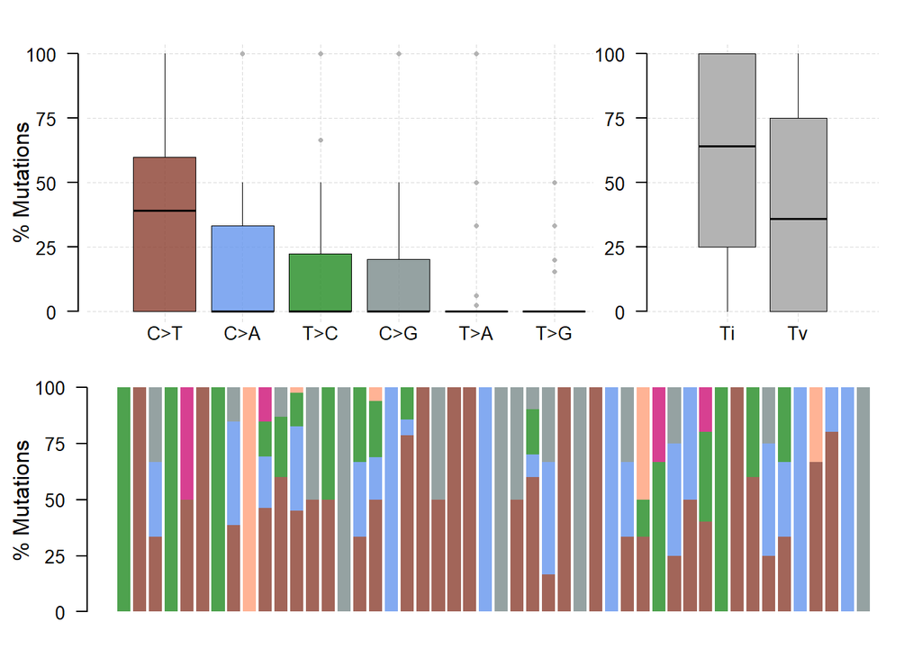

```r
BM_laml.titv = titv(maf = BM_laml, plot = FALSE, useSyn = TRUE)

#plot titv summary
plotTiTv(res = BM_laml.titv)
```

#### Mutation load vs TCGA cohorts

```r
laml.mutload = tcgaCompare(maf = BM_laml, cohortName = 'Example-LAML')
```

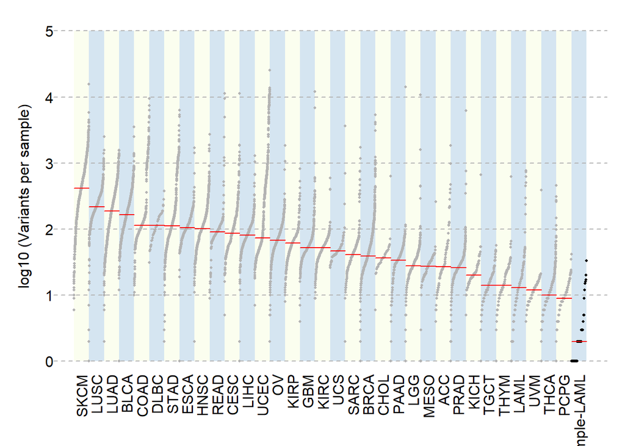

#### Somatic interactions

```r
somaticInteractions(maf = BM_laml, top = 30, pvalue = c(0.05, 0.1))
```

```
## $pairs
##         gene1     gene2      pValue oddsRatio 00 11 01 10        Event
##  1:      RIN2     GTF2I 0.001020408       Inf 44  3 NA  3 Co_Occurance
##  2:     KIF5C HIST1H2BD 0.001020408       Inf 44  3 NA  3 Co_Occurance
##  3:     VWA5A      PRPH 0.004897959       Inf 46  2 NA  2 Co_Occurance
##  4:     UTP20     GTF2I 0.006122449       Inf 40  3 NA  7 Co_Occurance
##  5:      PHF2     GTF2I 0.007244898 61.358137 46  2  1  1 Co_Occurance
##  6:   SLC17A7 HIST1H2BD 0.007244898 61.358137 46  2  1  1 Co_Occurance
##  7:     ASMTL      TYMS 0.008163265       Inf 45  2 NA  3 Co_Occurance
##  8:     KIF5C      PRPH 0.012244898       Inf 44  2 NA  4 Co_Occurance
##  9:  SERPINI1      TYMS 0.012244898       Inf 44  2 NA  4 Co_Occurance
## 10:     NSMAF      ABAT 0.014285714 35.351222 45  2  2  1 Co_Occurance
## 11: HIST1H2BD  HIST1H1C 0.014285714 35.351222 45  2  2  1 Co_Occurance
## 12:     NSMAF  KIAA0368 0.014285714 35.351222 45  2  2  1 Co_Occurance
## 13:      MCM5   RUNDC3B 0.014285714 35.351222 45  2  2  1 Co_Occurance
```

[output cut: 42 more lines]

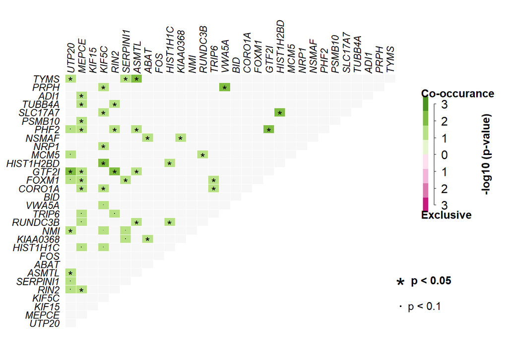

```
##           Length Class      Mode
## pairs     9      data.table list
## gene_sets 0      -none-     NULL
```

```r
summary(somaticInteractions(maf = BM_laml, top = 30, pvalue = c(0.05, 0.1)))
```

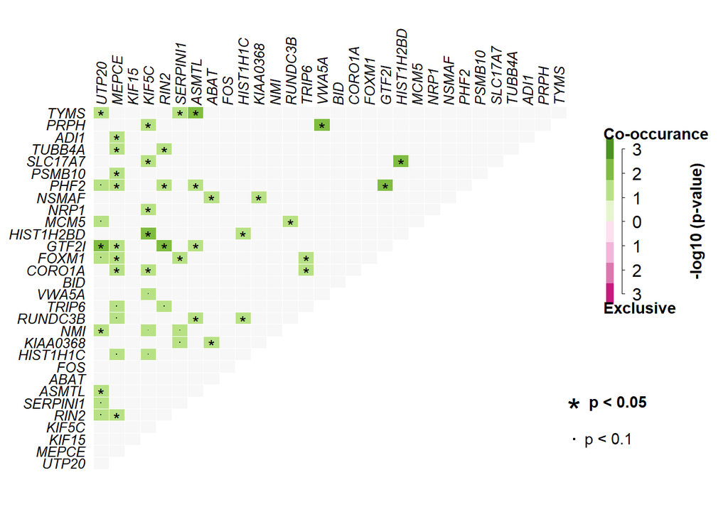

```
## [[1]]
## [[1]]$pairs
##         gene1     gene2      pValue oddsRatio 00 11 01 10        Event
##  1:      RIN2     GTF2I 0.001020408       Inf 44  3 NA  3 Co_Occurance
##  2:     KIF5C HIST1H2BD 0.001020408       Inf 44  3 NA  3 Co_Occurance
##  3:     VWA5A      PRPH 0.004897959       Inf 46  2 NA  2 Co_Occurance
##  4:     UTP20     GTF2I 0.006122449       Inf 40  3 NA  7 Co_Occurance
##  5:      PHF2     GTF2I 0.007244898 61.358137 46  2  1  1 Co_Occurance
##  6:   SLC17A7 HIST1H2BD 0.007244898 61.358137 46  2  1  1 Co_Occurance
##  7:     ASMTL      TYMS 0.008163265       Inf 45  2 NA  3 Co_Occurance
##  8:     KIF5C      PRPH 0.012244898       Inf 44  2 NA  4 Co_Occurance
##  9:  SERPINI1      TYMS 0.012244898       Inf 44  2 NA  4 Co_Occurance
## 10:     NSMAF      ABAT 0.014285714 35.351222 45  2  2  1 Co_Occurance
## 11: HIST1H2BD  HIST1H1C 0.014285714 35.351222 45  2  2  1 Co_Occurance
## 12:     NSMAF  KIAA0368 0.014285714 35.351222 45  2  2  1 Co_Occurance
```

[output cut: 43 more lines]

```r
pairlist(somaticInteractions(maf = BM_laml, top = 30, pvalue = c(0.05, 0.1)))
```

# Drug Gene interactions

```r
dgi = drugInteractions(maf = BM_laml, fontSize = 0.75)
```

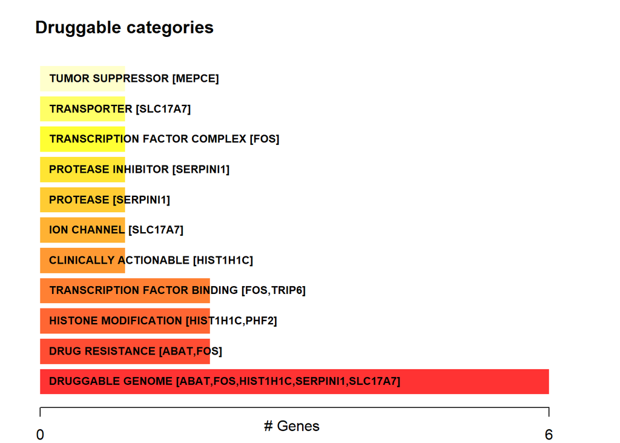

```r
dnmt3a.dgi = drugInteractions(genes = "MUC16", drugs = TRUE)
```

```
## Number of claimed drugs for given genes:
##     Gene  N
## 1: MUC16 15
```

```r
dnmt3a.dgi[,.(Gene, interaction_types, drug_name, drug_claim_name)]
```

```
##      Gene interaction_types         drug_name        drug_claim_name
##  1: MUC16                          ABAGOVOMAB          CHEMBL1742981
##  2: MUC16                                     DIFFERENTIATING AGENTS
##  3: MUC16                           DOCETAXEL              DOCETAXEL
##  4: MUC16                        CYCLOSPORINE           CYCLOSPORINE
##  5: MUC16                                                        N/A
##  6: MUC16                           TOPOTECAN              TOPOTECAN
##  7: MUC16                          OREGOVOMAB                 B43.13
##  8: MUC16                          ABAGOVOMAB             ABAGOVOMAB
##  9: MUC16                          OREGOVOMAB          CHEMBL2107917
## 10: MUC16                          OREGOVOMAB             OREGOVAMAB
## 11: MUC16                     SODIUM BUTYRATE        SODIUM BUTYRATE
## 12: MUC16                           TAMOXIFEN              TAMOXIFEN
## 13: MUC16                   BUSERELIN ACETATE      BUSERELIN ACETATE
## 14: MUC16                           ETOPOSIDE              ETOPOSIDE
## 15: MUC16                                                        IFN
```

```r
OncogenicPathways(maf = BM_laml)
```

```
## Pathway alteration fractions
```

```
##        Pathway  N n_affected_genes fraction_affected
##  1: Cell_Cycle 15                1        0.06666667
##  2:      Hippo 38                0        0.00000000
##  3:        MYC 13                0        0.00000000
##  4:      NOTCH 71                0        0.00000000
##  5:       NRF2  3                0        0.00000000
##  6:       PI3K 29                0        0.00000000
##  7:    RTK-RAS 85                0        0.00000000
##  8:   TGF-Beta  7                0        0.00000000
##  9:       TP53  6                0        0.00000000
## 10:        WNT 68                0        0.00000000
```

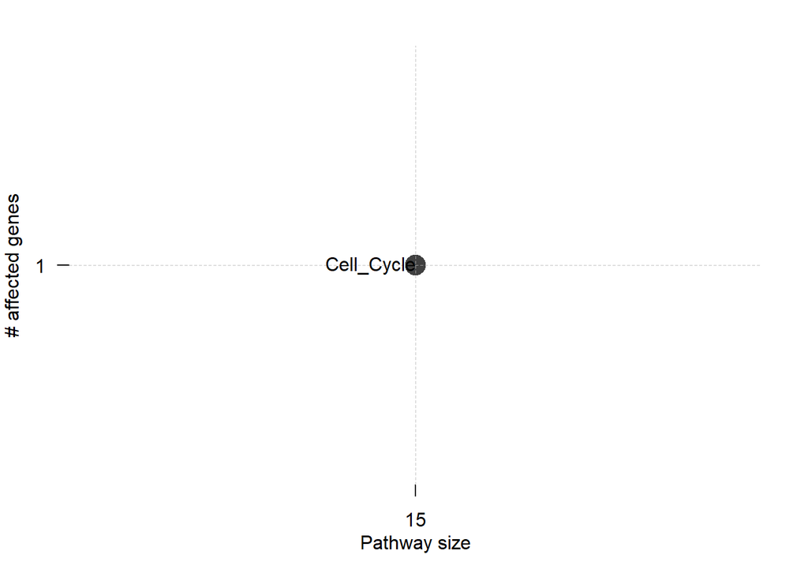